# Prediction Assignment Writeup

2025-11-25

## Introduction

The goal of this project is to predict the manner in which participants performed an exercise, using accelerometer data from wearable devices.

The outcome of interest is the variable classe in the training dataset. The five levels of classe represent different ways in which the exercise was performed (correctly or with various types of mistakes).

We will:

## Data loading

```
## [1] 19622   160
```

```
## [1]  20 160
```

## Data cleaning and preprocessing

### Remove variables with many missing values

We will first remove predictors that consist of mostly NA.

```r
# Set to NA for blanks and meaningless data
training_raw[training_raw == ""] <- NA
training_raw[training_raw == " "] <- NA
training_raw[training_raw == "#DIV/0!"] <- NA

testing_raw[testing_raw == ""] <- NA
testing_raw[testing_raw == " "] <- NA
testing_raw[testing_raw == "#DIV/0!"] <- NA

noNA_cols <- colSums(is.na(training_raw)) == 0

# Only keep the columns with no NAs
training_clean <- training_raw[, noNA_cols]
testing_clean  <- testing_raw[, noNA_cols]
```

### Remove non-meaningful predictors

Next, we will remove predictors which are not meaningful for predictions. These include row index, user name, and raw timestamps.

```r
id_vars <- c("X","user_name","raw_timestamp_part_1",
             "raw_timestamp_part_2","cvtd_timestamp")

training_clean <- training_clean[, !(names(training_clean) %in% id_vars)]
testing_clean  <- testing_clean[,  !(names(testing_clean) %in% id_vars)]
```

### Remove near-zero variance predictors

We will then remove predictors with non-zero variance i.e. same values for nearly all observations. Such predictors do not contribute to model accuracy and can slow down training or cause overfitting, so eliminating them improves model performance and stability.

```r
nzv <- nearZeroVar(training_clean, saveMetrics = TRUE)

training_clean <- training_clean[, !nzv$nzv]
testing_clean  <- testing_clean[,  !nzv$nzv]
```

## Training/Validation Split

While here is a separate test file (pml-testing.csv), we still need an internal validation set from the training data to estimate out-of-sample performance.

```r
set.seed(12345)
inTrain <- createDataPartition(training_clean$classe, p = 0.7, list = FALSE)
train_set <- training_clean[inTrain, ]
valid_set <- training_clean[-inTrain, ]

dim(train_set)
```

```
## [1] 13737    54
```

```r
dim(valid_set)
```

```
## [1] 5885   54
```

```r
train_set$classe <- factor(train_set$classe)
valid_set$classe <- factor(valid_set$classe)
```

## Model Training

We will use a Random Forest model, which tends to have better perfoamnce on high-dimensional classification tasks. We will use 5-fold cross-validation within the training set to tune the model and estimate model performance.

```r
ctrl <- trainControl(
method = "cv",
number = 5,
verboseIter = FALSE
)

set.seed(12345)
fit_rf <- train(
classe ~ .,
data = train_set,
method = "rf",
trControl = ctrl
)

fit_rf
```

```
## Random Forest
##
## 13737 samples
##    53 predictor
##     5 classes: 'A', 'B', 'C', 'D', 'E'
##
## No pre-processing
## Resampling: Cross-Validated (5 fold)
## Summary of sample sizes: 10990, 10990, 10989, 10991, 10988
## Resampling results across tuning parameters:
##
##   mtry  Accuracy   Kappa
##    2    0.9941033  0.9925409
##   27    0.9973794  0.9966851
##   53    0.9946858  0.9932771
##
## Accuracy was used to select the optimal model using the largest value.
## The final value used for the model was mtry = 27.
```

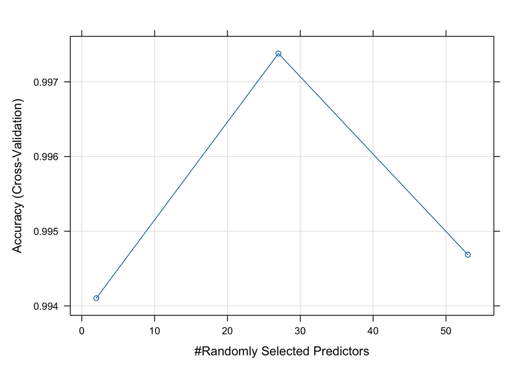

```r
plot(fit_rf)
```

```r
max(fit_rf$results$Accuracy)
```

```
## [1] 0.9973794
```

This shows that the random forest model fits the training data very well under cross-validation.

## Model Evaluation

To estimate the out-of-sample performance, we evaluate the fitted model on the held-out validation set.

```r
pred_valid <- predict(fit_rf, valid_set)
cm_rf <- confusionMatrix(pred_valid, valid_set$classe)
cm_rf
```

```
## Confusion Matrix and Statistics
##
##           Reference
## Prediction    A    B    C    D    E
##          A 1674    1    0    0    0
##          B    0 1138    1    0    0
##          C    0    0 1025    2    0
##          D    0    0    0  962    1
##          E    0    0    0    0 1081
##
## Overall Statistics
##
##                Accuracy : 0.9992
##                  95% CI : (0.998, 0.9997)
##     No Information Rate : 0.2845
##     P-Value [Acc > NIR] : < 2.2e-16
##
##                   Kappa : 0.9989
##
##  Mcnemar's Test P-Value : NA
##
## Statistics by Class:
##
##                      Class: A Class: B Class: C Class: D Class: E
## Sensitivity            1.0000   0.9991   0.9990   0.9979   0.9991
## Specificity            0.9998   0.9998   0.9996   0.9998   1.0000
## Pos Pred Value         0.9994   0.9991   0.9981   0.9990   1.0000
## Neg Pred Value         1.0000   0.9998   0.9998   0.9996   0.9998
## Prevalence             0.2845   0.1935   0.1743   0.1638   0.1839
## Detection Rate         0.2845   0.1934   0.1742   0.1635   0.1837
## Detection Prevalence   0.2846   0.1935   0.1745   0.1636   0.1837
## Balanced Accuracy      0.9999   0.9995   0.9993   0.9989   0.9995
```

```r
cm_rf$overall["Accuracy"]
```

```
##  Accuracy
## 0.9991504
```

Using a Random Forest model with 5-fold cross-validation and tuned mtry, the model achieved an accuracy of 99.92% on the validation set (95% CI: 99.80%–99.97%), with a Kappa of 0.9989. Misclassification was extremely rare across all five classes, suggesting that the model generalizes very well to unseen data. The estimated out-of-sample error is therefore approximately 0.08%.

## Validation Accuracy and Estimated Out-of-Sample Error

```r
# Overall accuracy from the confusion matrix
valid_accuracy <- as.numeric(cm_rf$overall["Accuracy"])
valid_accuracy
```

```
## [1] 0.9991504
```

```r
# Estimated out-of-sample error
oos_error <- 1 - valid_accuracy
oos_error
```

```
## [1] 0.0008496177
```

The random forest model achieved a validation accuracy of 0.9991504, corresponding to an estimated out-of-sample error of approximately 0.0008496177.

## Final Model Fit on Full Training Data

Since the random forest model performed extremely well on the validation set, we now refit the model on the entire cleaned training dataset to maximize the data used for learning. We reuse the best tuning parameter (`mtry`) found earlier.

```r
# Use the best mtry from the cross-validated model
best_mtry <- fit_rf$bestTune$mtry
best_mtry
```

```
## [1] 27
```

```r
ctrl_final <- trainControl(method = "none")

set.seed(12345)
fit_rf_final <- train(
  classe ~ .,
  data = training_clean,
  method = "rf",
  trControl = ctrl_final,
  tuneGrid = data.frame(mtry = best_mtry)
)

fit_rf_final
```

```
## Random Forest
##
## 19622 samples
##    53 predictor
##     5 classes: 'A', 'B', 'C', 'D', 'E'
##
## No pre-processing
## Resampling: None
```

## Predictions for the 20 Test Cases

Finally the final random forest model is applied to the test set (`testing_clean`) to obtain predictions for the 20 cases required.

```r
final_predictions <- predict(fit_rf_final, testing_clean)
final_predictions
```

```
##  [1] B A B A A E D B A A B C B A E E A B B B
## Levels: A B C D E
```